# 4. Data exploration and visualisation in camtrapR

Juergen Niedballa (camtrapr@gmail.com)

2020-07-29

```r
library(camtrapR)
```

# Overview

camtrapR can help with data exploration by creating maps of observed species richness and the number of independent detections by species. It can also plot single-species and two-species diel activity data. In addition, a survey report summarising camera trap station operation and species records can be created easily. The usage of these functions will be demonstrated using the sample data set included in the package.

In creating the plots and the report, the species record table and the camera trap station information table are combined. Therefore, both are required as function input (more details in the vignette on “Image organisation and species/individual identification”).

```r
# load sample camera trap station table
data(camtraps)

# load sample record table
data(recordTableSample)
```

# Species presence maps

The function `detectionMaps` can generate maps of observed species richness (number of different species recorded at stations) and maps showing the number of observations by species. It uses the record table produced by `recordTable` and the camera trap station table as input. Note that the examples are not particularly pretty because of the low number of records used in the sample data set.

## Number of observed species

We first create a map of the number of observed species.

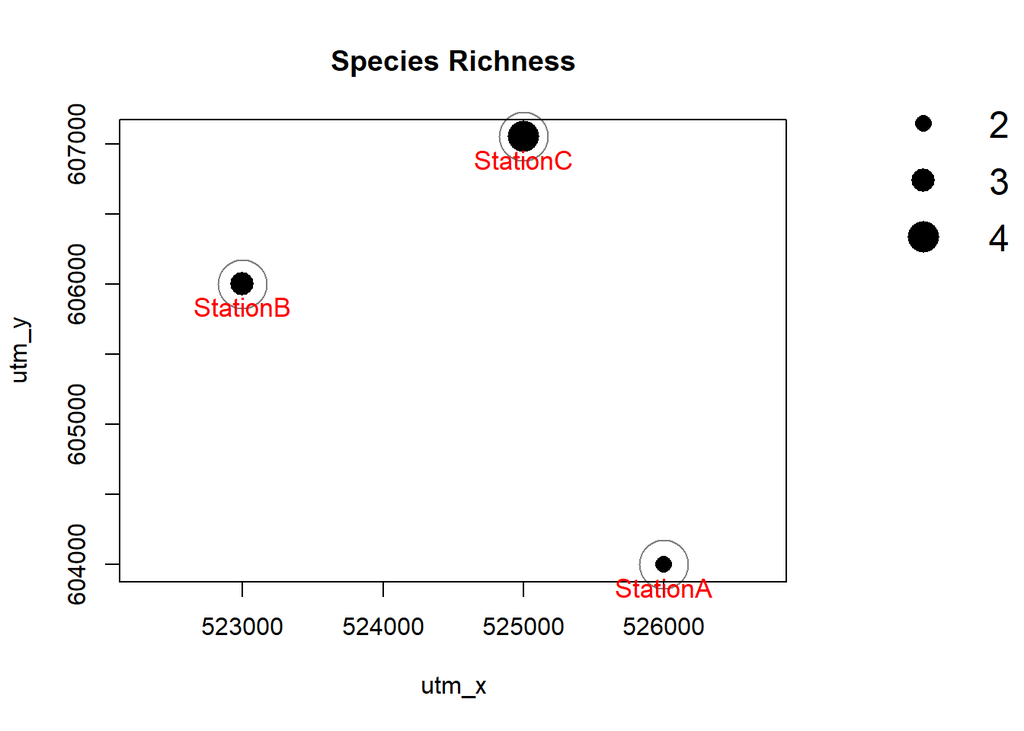

```r
Mapstest1 <- detectionMaps(CTtable     = camtraps,
                          recordTable  = recordTableSample,
                          Xcol         = "utm_x",
                          Ycol         = "utm_y",
                          stationCol   = "Station",
                          speciesCol   = "Species",
                          printLabels  = TRUE,
                          richnessPlot = TRUE,    # by setting this argument TRUE
                          speciesPlots = FALSE,
                          addLegend    = TRUE
)
```

## Number of records by species

Maps of the number of independent detections of the observed species can be generated just as easily. Normally, maps for all species will be created at once. Here, to avoid cluttering the vignette, we look at one species only. This is achieved via the argument `speciesToShow`. Arguments `richnessPlot` and `speciesPlots` are changed compared to the observed species richness plot above. It is also possible to set both arguments to TRUE or FALSE.

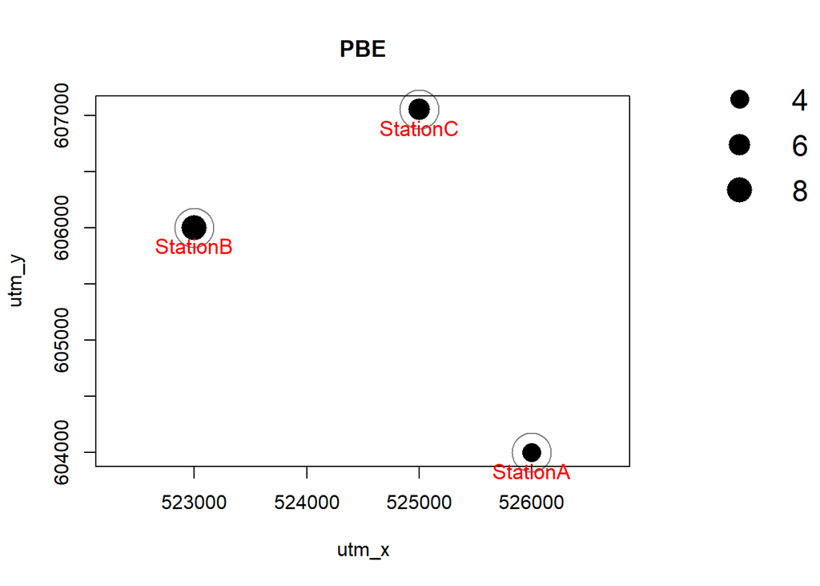

```r
 # subset to 1 species
recordTableSample_PBE <- recordTableSample[recordTableSample$Species == "PBE",]

 Mapstest2 <- detectionMaps(CTtable      = camtraps,
                           recordTable   = recordTableSample_PBE,
                           Xcol          = "utm_x",
                           Ycol          = "utm_y",
                           stationCol    = "Station",
                           speciesCol    = "Species",
                           speciesToShow = "PBE",     # added
                           printLabels   = TRUE,
                           richnessPlot  = FALSE,     # changed
                           speciesPlots  = TRUE,      # changed
                           addLegend     = TRUE
)
```

The number of independent observations depends on the argument `minDeltaTime` in the `recordTable` function.

## Shapefile export

Function `detectionMaps` comes with 4 arguments that allow for and control creation of ESRI shapefile for use in GIS software: `writeShapefile`, `shapefileName`, `shapefileDirectory` and `shapefileProjection`. The resulting shapefile will show stations as point features (as the map above), with coordinates, total species number and number of observations per species in the attribute table. The shapefile attribute table is identical to the resulting `data.frame` of the `detectionMaps` function.

The following example demonstrates the creation of a shapefile using `detectionMaps`. Please note that for demonstration the shapefile is saved to a temporary directory, which makes no sense in real data and must be changed by the user. The argument `shapefileProjection` must be a valid argument to the function `CRS` from the package `sp`, i.e., a PROJ.4 string. These can be found under http://spatialreference.org/. There, find the projection your coordinates are in, click on “Proj4” and copy the text. In this example, it is a projected coordinate system, UTM 50N with the WGS84 ellipsoid. Its PROJ.4 string is "+proj=utm +zone=50 +ellps=WGS84 +datum=WGS84 +units=m +no_defs". Because it is so widespread, here’s the PROJ4 string for standard Lat/Long coordinates using the WGS84 ellipsoid (a standard used by most GPS devices): "+proj=longlat +ellps=WGS84 +datum=WGS84 +no_defs".

```r
# writing shapefiles requires packages rgdal and sp
 library(rgdal)
 library(sp)
```

```r
 # define shapefile name
 shapefileName       <- "recordShapefileTest"
 shapefileProjection <- "+proj=utm +zone=50 +ellps=WGS84 +datum=WGS84 +units=m +no_defs"

# run detectionMaps with shapefile creation
Mapstest3 <- detectionMaps(CTtable            = camtraps,
                          recordTable         = recordTableSample,
                          Xcol                = "utm_x",
                          Ycol                = "utm_y",
                          stationCol          = "Station",
                          speciesCol          = "Species",
                          richnessPlot        = FALSE,         # no richness plot
                          speciesPlots        = FALSE,         # no species plots
                          writeShapefile      = TRUE,          # but shaepfile creation
                          shapefileName       = shapefileName,
                          shapefileDirectory  = tempdir(),     # change this in your scripts!
                          shapefileProjection = shapefileProjection
)

# check for the files that were created
list.files(tempdir(), pattern = shapefileName)
```

```
## [1] "recordShapefileTest.dbf" "recordShapefileTest.prj"
## [3] "recordShapefileTest.shp" "recordShapefileTest.shx"
```

```r
# load it as shapefile
shapefileTest <- readOGR(dsn   = tempdir(),
                         layer = shapefileName)
# we have a look at the attribute table
shapefileTest@data
```

```
##    Station  utm_y  utm_x EGY MNE PBE TRA VTA n_species
## 1 StationA 604000 526000   0   0   4   0   2         2
## 2 StationB 606000 523000   0   2   8   0   2         3
## 3 StationC 607050 525000   6   0   6   8   1         4
```

```r
# the output of detectionMaps is used as shapefile attribute table. Therefore, they are identical:
all(shapefileTest@data == Mapstest3)
```

```
## [1] TRUE
```

## Making and using a SpatialPointsDataFrame

The data frame that `detectionMaps` returns can be turned into a SpatialPointsDataFrame as defined in the package `sp`. SpatialPointsDataFrames can be used for spatial analyses and queries in R, e.g. for extracting data from raster layers such as elevation maps.

This is how it works. We use the output of `detectionMaps` created above and make a SpatialPointsDataFrame. Afterwards, a sample raster is created, plotted together with the points and the values are extracted.

```r
detections_spdf <- SpatialPointsDataFrame(coords      = Mapstest3[,c("utm_x", "utm_y")],
                                          data        = Mapstest3,
                                          proj4string = CRS(shapefileProjection))

str(detections_spdf)
```

```
## Formal class 'SpatialPointsDataFrame' [package "sp"] with 5 slots
##   ..@ data       :'data.frame':  3 obs. of  9 variables:
##   .. ..$ Station  : chr [1:3] "StationA" "StationB" "StationC"
##   .. ..$ utm_y    : num [1:3] 604000 606000 607050
##   .. ..$ utm_x    : num [1:3] 526000 523000 525000
##   .. ..$ EGY      : int [1:3] 0 0 6
##   .. ..$ MNE      : int [1:3] 0 2 0
##   .. ..$ PBE      : int [1:3] 4 8 6
##   .. ..$ TRA      : int [1:3] 0 0 8
##   .. ..$ VTA      : int [1:3] 2 2 1
##   .. ..$ n_species: int [1:3] 2 3 4
##   ..@ coords.nrs : num(0)
##   ..@ coords     : num [1:3, 1:2] 526000 523000 525000 604000 606000 ...
##   .. ..- attr(*, "dimnames")=List of 2
##   .. .. ..$ : NULL
##   .. .. ..$ : chr [1:2] "utm_x" "utm_y"
##   ..@ bbox       : num [1:2, 1:2] 523000 604000 526000 607050
##   .. ..- attr(*, "dimnames")=List of 2
##   .. .. ..$ : chr [1:2] "utm_x" "utm_y"
##   .. .. ..$ : chr [1:2] "min" "max"
##   ..@ proj4string:Formal class 'CRS' [package "sp"] with 1 slot
##   .. .. ..@ projargs: chr "+proj=utm +zone=50 +datum=WGS84 +units=m +no_defs"
```

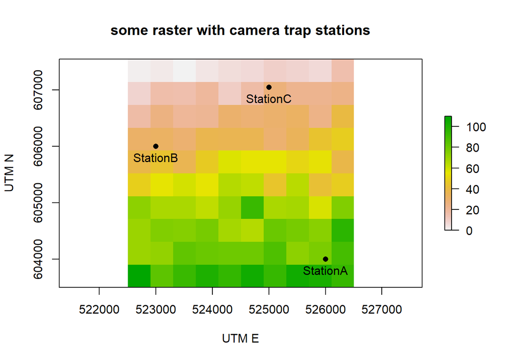

```
##    Station  utm_y  utm_x EGY MNE PBE TRA VTA n_species raster_value
## 1 StationA 604000 526000   0   0   4   0   2         2           77
## 2 StationB 606000 523000   0   2   8   0   2         3           32
## 3 StationC 607050 525000   6   0   6   8   1         4           27
```

```r
# now we create a sample raster and extract data from it (if the raster package is available)
if("raster" %in% installed.packages()){
  library(raster)
  raster_test <- raster(x = extend(extent(detections_spdf), y = 500), nrows = 10, ncols = 10)
  values(raster_test) <- rpois(n = 100, lambda = seq(1, 100))    # fill raster with random numbers

  # plot raster
  plot(raster_test,
       main = "some raster with camera trap stations",
       ylab = "UTM N",     # needs to be adjusted if data are not in UTM coordinate system
       xlab = "UTM E")     # needs to be adjusted if data are not in UTM coordinate system

  # add points to plot
  points(detections_spdf, pch = 16)

  # add point labels
  text(x      = coordinates(detections_spdf)[,1],
       y      = coordinates(detections_spdf)[,2],
       labels = detections_spdf$Station,
       pos = 1)

  # extracting raster values. See ?extract for more information
  detections_spdf$raster_value <- extract(x = raster_test, y = detections_spdf)

  # checking the attribute table
  detections_spdf@data

}
```

The same procedure also works with the camera trap station information table instead of the `detectionMaps` output.

# Visualising species activity data

Four different functions are provided to plot single-species and two-species activity patterns. Activity data are visualised using the time of day records were taken while ignoring the date. Record times are read from the record table created by `recordTable`. The criterion for temporal independence between records in the function `recordTable`, `minDeltaTime`, will affect the results of the activity plots. Imagine you make `recordTable` return all records by setting `minDeltaTime = 0` and you then plot activity of some species that loves to perform in front of cameras (e.g. Great Argus pheasants in Borneo), resuting in hundreds of images. The representation of activity will be biased towards the times the species happened to perform in front of your cameras. Likewise, setting cameras to shoot sequences of several images per trigger event and then returning all images will cause biased representations. Therefore, it is wise to set `minDeltaTime` to some higher number, e.g. 60 (minutes).

If desired, all functions can save the plots as png files by setting argument `writePNG = TRUE`.

## Single-species activity plots

Single-species activity can be plotted in 3 different ways using 3 different functions:

1. `activityDensity`: kernel density estimation
2. `activityHistogram`: histogram of hourly activity
3. `activityRadial`: radial plot of hourly activity

In all three, users can either plot activity of one focal species (by setting argument `allSpecies = FALSE`) or of all recorded species at once (by setting argument `allSpecies = TRUE`). If desired, plots can be saved as png files in a user-defined location automatically (arguments `writePNG` and `plotDirectory`). Note that the examples are not particularly pretty because of the low number of records used in the sample data set.

```r
# we first pick a species for our activity trials
species4activity <- "PBE"    # = Prionailurus bengalensis, Leopard Cat
```

### Kernel density estimation

`activityDensity` uses the function `densityPlot` from the `overlap` package.

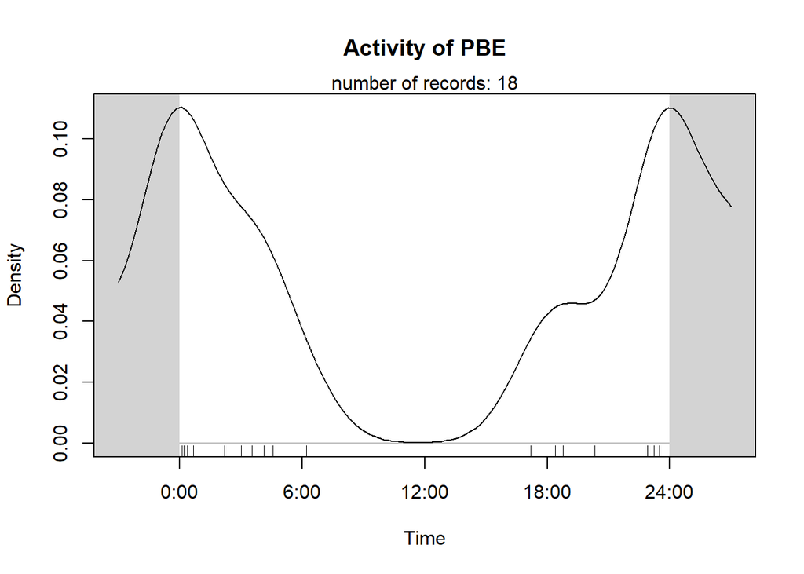

```r
activityDensity(recordTable = recordTableSample,
                species     = species4activity)
```

### Histogram

This function creates a histogram with hourly intervals, i.e. histogram cells are 1 hour wide.

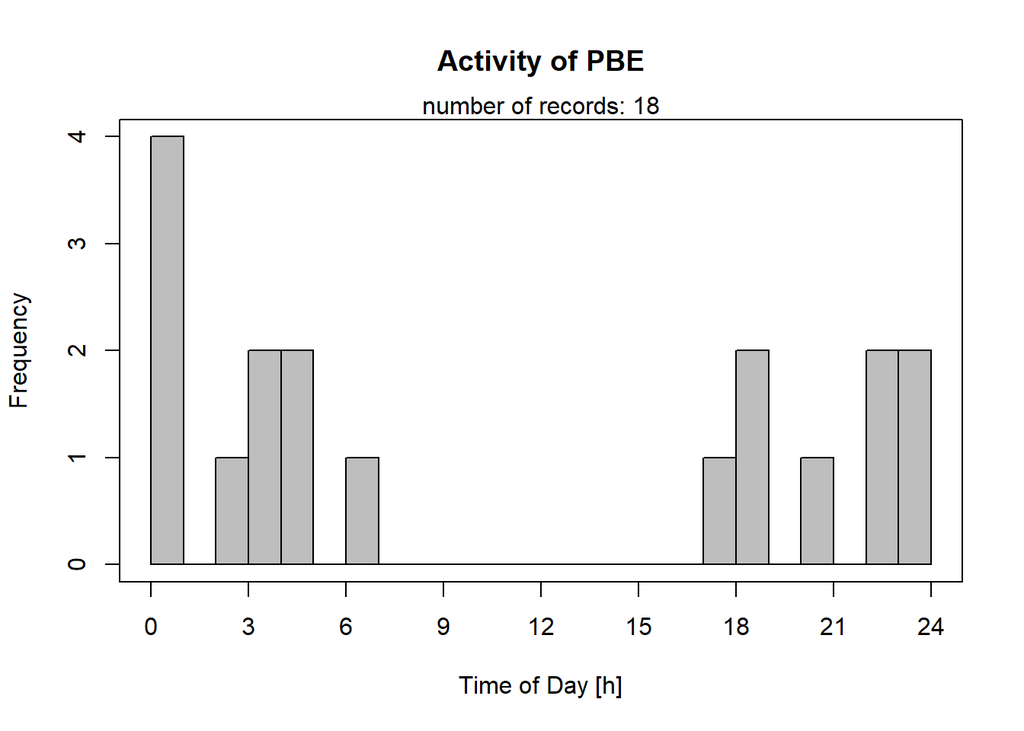

```r
activityHistogram (recordTable = recordTableSample,
                   species     = species4activity)
```

### Radial plot

This function uses functions from the `plotrix` package to create the clock face. Records are aggregated to the full hour (as in `activityHistogram`).

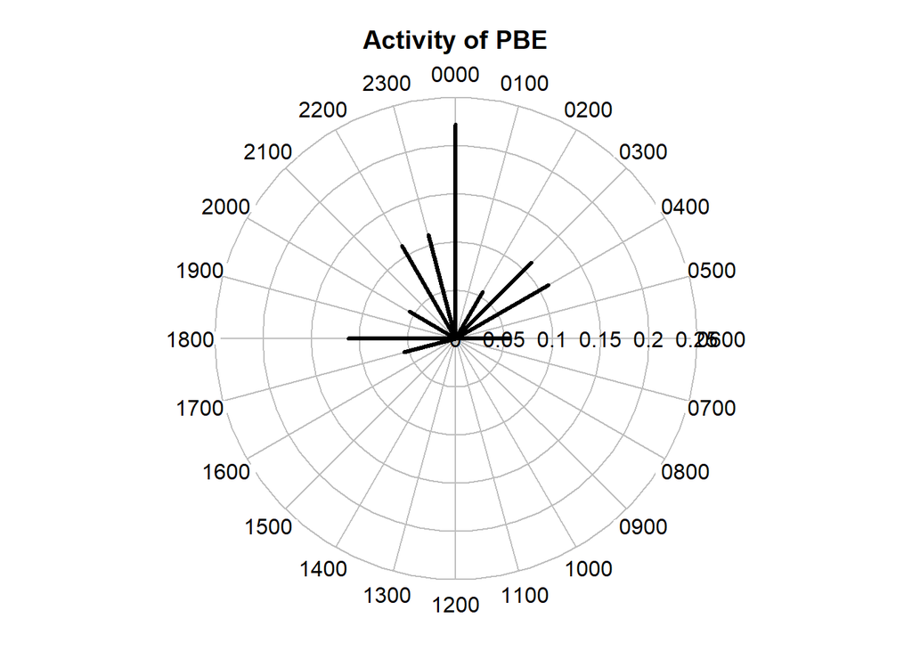

```r
activityRadial(recordTable  = recordTableSample,
               species      = species4activity,
               lwd          = 3       # adjust line with of the plot
)
```

One can also make the function show a polygon instead of the radial lines. `rp.type` is an argument to `radial.plot` and defaults to `"r"` (radial). Setting it to `"p"` gives a polygon.

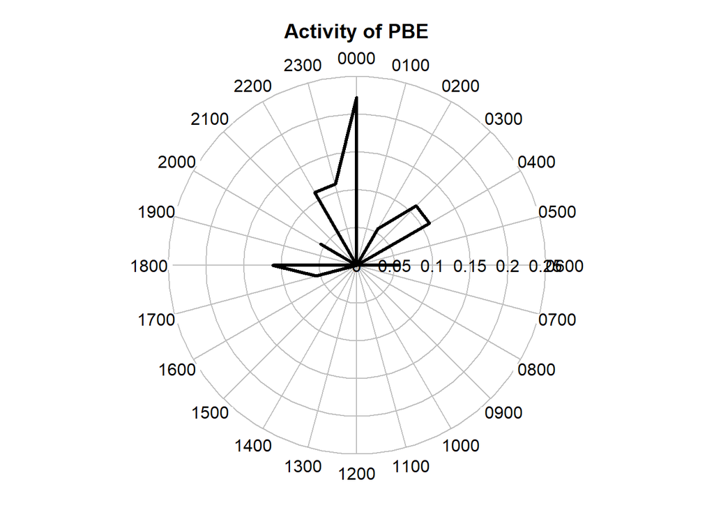

```r
activityRadial(recordTable       = recordTableSample,
               species           = species4activity,
               allSpecies        = FALSE,
               speciesCol        = "Species",
               recordDateTimeCol = "DateTimeOriginal",
               plotR             = TRUE,
               writePNG          = FALSE,
               lwd               = 3,
               rp.type           = "p"      # plot type = polygon
)
```

## Two-species activity plots

Two-species activity overlaps can be plotted in addition to single-species activity plots. It is the overlap between two single-species kernel density estimations. The functions `overlapPlot` and `overlapEst` from the `overlap` package are used for that purpose. The overlap coefficient shown in the plot is Dhat1 from `overlapEst`.

[figure not shown]

```r
# define species of interest
speciesA_for_activity <- "VTA"    # = Viverra tangalunga, Malay Civet
speciesB_for_activity <- "PBE"    # = Prionailurus bengalensis, Leopard Cat

# create activity overlap plot
activityOverlap (recordTable = recordTableSample,
                 speciesA    = speciesA_for_activity,
                 speciesB    = speciesB_for_activity,
                 writePNG    = FALSE,
                 plotR       = TRUE,
                 add.rug     = TRUE
)
```

This plot an be customised by passing additional arguments to `overlapPlot`:

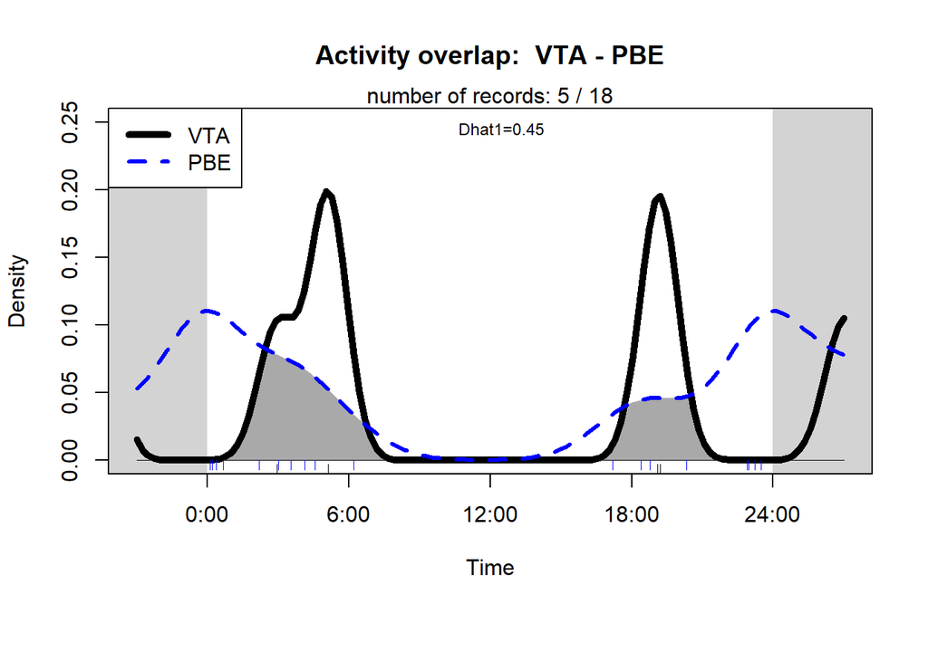

```r
activityOverlap (recordTable = recordTableSample,
                 speciesA    = speciesA_for_activity,
                 speciesB    = speciesB_for_activity,
                 writePNG    = FALSE,
                 plotR       = TRUE,
                 createDir   = FALSE,
                 pngMaxPix   = 1000,
                 linecol     = c("black", "blue"),
                 linewidth   = c(5,3),
                 linetype    = c(1, 2),
                 olapcol     = "darkgrey",
                 add.rug     = TRUE,
                 extend      = "lightgrey",
                 ylim        = c(0, 0.25),
                 main        = paste("Activity overlap: ", speciesA_for_activity, "-", speciesB_for_activity)
)
```

# Survey summary report

`surveyReport` conveniently creates a summary report containing:

- number of stations (total and operational)
- number of active trap days (total and by station)
- number of days with cameras set up (operational or not; total and by station)
- total trapping period
- camera trap and record date ranges
- number of species by station
- number of independent events by species
- number of stations at which species were recorded
- number of independent events by station and species

```r
reportTest <- surveyReport (recordTable          = recordTableSample,
                            CTtable              = camtraps,
                            speciesCol           = "Species",
                            stationCol           = "Station",
                            setupCol             = "Setup_date",
                            retrievalCol         = "Retrieval_date",
                            CTDateFormat         = "%d/%m/%Y",
                            recordDateTimeCol    = "DateTimeOriginal",
                            recordDateTimeFormat = "%Y-%m-%d %H:%M:%S",
                            CTHasProblems        = TRUE)
```

```
##
## -------------------------------------------------------
## [1] "Total number of stations:  3"
##
## -------------------------------------------------------
## [1] "Number of operational stations:  3"
##
## -------------------------------------------------------
## [1] "n nights with cameras set up (operational or not. NOTE: only correct if 1 camera per station): 128"
##
## -------------------------------------------------------
## [1] "n nights with cameras set up and active (trap nights. NOTE: only correct if 1 camera per station): 123"
##
## -------------------------------------------------------
## [1] "total trapping period:  2009-04-02 - 2009-05-17"
```

Some basic information is shown in the console. The function output is a list with 5 elements.

```r
str(reportTest)
```

```
## List of 5
##  $ survey_dates      :'data.frame':  3 obs. of  8 variables:
##   ..$ Station         : chr [1:3] "StationA" "StationB" "StationC"
##   ..$ setup_date      : Date[1:3], format: "2009-04-02" "2009-04-03" ...
##   ..$ first_image_date: Date[1:3], format: "2009-04-10" "2009-04-05" ...
##   ..$ last_image_date : Date[1:3], format: "2009-05-07" "2009-05-14" ...
##   ..$ retrieval_date  : Date[1:3], format: "2009-05-14" "2009-05-16" ...
##   ..$ n_nights_total  : int [1:3] 42 43 43
##   ..$ n_nights_active : num [1:3] 42 43 38
##   ..$ n_cameras       : int [1:3] 1 1 1
##  $ species_by_station:'data.frame':  3 obs. of  2 variables:
##   ..$ Station  : chr [1:3] "StationA" "StationB" "StationC"
##   ..$ n_species: int [1:3] 2 3 4
##  $ events_by_species :'data.frame':  5 obs. of  3 variables:
##   ..$ species   : chr [1:5] "EGY" "MNE" "PBE" "TRA" ...
##   ..$ n_events  : chr [1:5] "6" "2" "18" "8" ...
##   ..$ n_stations: chr [1:5] "1" "1" "3" "1" ...
##  $ events_by_station :'data.frame':  9 obs. of  3 variables:
##   ..$ Station : chr [1:9] "StationA" "StationA" "StationB" "StationB" ...
##   ..$ Species : chr [1:9] "PBE" "VTA" "MNE" "PBE" ...
##   ..$ n_events: int [1:9] 4 2 2 8 2 6 6 8 1
##  $ events_by_station2:'data.frame':  15 obs. of  3 variables:
##   ..$ Station : Factor w/ 3 levels "StationA","StationB",..: 1 1 1 1 1 2 2 2 2 2 ...
##   ..$ Species : Factor w/ 5 levels "EGY","MNE","PBE",..: 1 2 3 4 5 1 2 3 4 5 ...
##   ..$ n_events: num [1:15] 0 0 4 0 2 0 2 8 0 2 ...
```

The list elements can be accessed individually like this: `reportTest[[1]]` or like this: `reportTest$survey_dates`.

Some of the arguments need further explanations. `CTHasProblems` is used to tell camtrapR whether to look for columns specifying periods of malfunctioning in `CTtable` (e.g. ‘Problem1_from’ and ‘Problem1_to’). If there was more than one camera per station `cameraCol` specifies the columns containing camera IDs . Not setting it will cause camtrapR to assume there was 1 camera per station, biasing the trap day calculation. `sinkpath` can optionally be a directory in which the function will save the output as a txt file.

```r
# here's the output of surveyReport

reportTest[[1]]    # camera trap operation times and image date ranges
```

```
##    Station setup_date first_image_date last_image_date retrieval_date
## 1 StationA 2009-04-02       2009-04-10      2009-05-07     2009-05-14
## 2 StationB 2009-04-03       2009-04-05      2009-05-14     2009-05-16
## 3 StationC 2009-04-04       2009-04-06      2009-05-12     2009-05-17
##   n_nights_total n_nights_active n_cameras
## 1             42              42         1
## 2             43              43         1
## 3             43              38         1
```

```r
reportTest[[2]]    # number of species by station
```

```
##    Station n_species
## 1 StationA         2
## 2 StationB         3
## 3 StationC         4
```

```r
reportTest[[3]]    # number of events and number of stations by species
```

```
##   species n_events n_stations
## 1     EGY        6          1
## 2     MNE        2          1
## 3     PBE       18          3
## 4     TRA        8          1
## 5     VTA        5          3
```

```r
reportTest[[4]]    # number of species events by station
```

```
##    Station Species n_events
## 1 StationA     PBE        4
## 2 StationA     VTA        2
## 3 StationB     MNE        2
## 4 StationB     PBE        8
## 5 StationB     VTA        2
## 6 StationC     EGY        6
## 7 StationC     PBE        6
## 8 StationC     TRA        8
## 9 StationC     VTA        1
```

```r
# reportTest[[5]] is identical to reportTest[[4]] except for the fact that it contains unobserved species with n_events = 0
```

## Survey summary report zip file

A zip file containing the output of `surveyReport`, the input tables, activity plots, detection maps and a prepared R script can be created by setting `makezip = TRUE`. The zip file is relatively small and can easily be used for data sharing with colleagues.

## Data archiving

The tables provided by the function `surveyReport` together with the camera station table and the record table provide key information about surveys. These data can be used for archiving survey data in online repositories such as the Knowledge Network for Biocomplexity ([KNB](https://knb.ecoinformatics.org)), a DataONE member node (https://www.dataone.org). To make these survey data understandable and usable for everyone, they need to be described thoroughly by metadata. Because of the amount of metadata needed to adequately describe the survey data and the technical requirement involved, we recommend using external software (e.g. [Morpho](https://knb.ecoinformatics.org/#tools/morpho)) for annotating data generated with camtrapR before upload to repositories.